# Authors

- Aziz Alabduljalil
- Abduarraheem Elfandi

## Disclaimer

Each section is divided between two subsections: Coaches and Teams, and Defence Players and Goalkeepers. The first subsection will explore the first and second questions, while the second subsection explores the third and fourth questions.

## Install libraries

```r
install.packages("caret")
install.packages("glmnet")
install.packages("tidyverse")
install.packages("ggrepel")
install.packages("randomForest")
install.packages("ROCR")
install.packages("kableExtra")
install.packages("vtable")
install.packages("corrplot")
```

## Load libraries

```r
library("caret")
library("glmnet")
library("tidyverse")
library("dplyr")
library("ggplot2")
library("ggrepel")
library("randomForest")
library("ROCR")
library("kableExtra")
library("vtable")
library("corrplot")
require(data.table)
```

# Data

Our data consists of three datasets: “male_teams.csv”, “male_players (legacy).csv”, and “male_coaches.csv”. It contains data on national and club teams from 2015-2023. The data is scraped from the FIFA games produced annually. While our research concerns real-life players and teams, the stats in the games require teams of observers watching real matches for months to decide. Thus, we will treat the data as if it applies to the real players and teams.

The dataset can be found at https://www.kaggle.com/datasets/stefanoleone992/fifa-23-complete-player-dataset.

## Load datasets

```r
teams <- read.csv("./male_teams.csv")
players <- read.csv("./male_players (legacy).csv")
coaches <- read.csv("./male_coaches.csv")
```

## Processing

### Teams

For the teams dataset, we wanted to focus on teams who had more than one coach to gauge the impact each coach left on the teams overall stats.

```r
newTeams <- data.frame(matrix(ncol = 54, nrow = 0))
colnames(newTeams) <- names(teams)
for (team in unique(teams$team_id)) {
    team_df <- subset(teams, team_id == team)

    if (length(unique(team_df$coach_id)) > 1) {
        newTeams <- rbind(newTeams, team_df)
    }
}

# Replaces NA values in coach_id column with a random coach_id
newTeams$coach_id[is.na(newTeams$coach_id)] <- sample.int(37666625, 1, replace = TRUE)

newTeams <- newTeams[, colSums(is.na(newTeams)) == 0] # Remove all columns with any NA values in them
```

| x |
| --- |
| team_id |
| team_url |
| fifa_version |
| fifa_update |
| fifa_update_date |
| team_name |
| league_id |
| league_name |
| nationality_id |
| nationality_name |
| overall |
| attack |
| midfield |
| defence |
| coach_id |
| home_stadium |
| rival_team |
| international_prestige |
| domestic_prestige |
| starting_xi_average_age |
| whole_team_average_age |
| def_style |
| def_defence_defender_line |
| off_style |
| off_build_up_play |
| off_chance_creation |
| build_up_play_positioning |
| chance_creation_positioning |

### Players

The same was done with the players dataset. To prevent using a large dataset, players were reduced to the first 3000 unique defence players. With each player having an entry for each FIFA update, the dataset grows large. each row then had that defence player’s goalkeeper and goalkeeper overall for that FIFA update to help our models later answer our thrid and fourth questions.

The same treatment of omitting NA columns was done to the players dataset, leaving 105 columns as shown below:

```r
modifiedPlayers <- subset(players, club_position %in%
    c("CB", "LB", "RB", "RWB", "LWB"))

modifiedPlayers <- subset(modifiedPlayers, short_name %in%
    unique(modifiedPlayers$short_name)[1:3000])

gkPlayers <- subset(players, club_position == "GK")

modifiedPlayers["gkName"] <- NA
modifiedPlayers["gkOverall"] <- NA


for (row in seq_len(nrow(modifiedPlayers))) {
    date <- as.Date(modifiedPlayers[row, "club_joined_date"])
    formattedFifaUpdate <- as.Date(modifiedPlayers$fifa_update_date)
    index <- which.min(abs(formattedFifaUpdate - date))

    filterData <- subset(
        gkPlayers,
        as.Date(fifa_update_date) >= as.Date(modifiedPlayers$fifa_update_date[index]) &
            club_team_id == modifiedPlayers[row, "club_team_id"]
    )

    if (nrow(filterData) != 0) {
        modifiedPlayers[row, ]$gkName <- filterData$short_name[1]
        modifiedPlayers[row, ]$gkOverall <- filterData$overall[1]
    }
}

# Replaces NA values in gkOverall column with median of gkOverall
val <- median(na.omit(modifiedPlayers$gkOverall))
modifiedPlayers$gkOverall[is.na(modifiedPlayers$gkOverall)] <- val

modifiedPlayers$gkName[is.na(modifiedPlayers$gkName)] <- "None"

newPlayers <- modifiedPlayers[, colSums(is.na(modifiedPlayers)) == 0] # Remove all columns with any NA values in them

# Remove arithmetic signs from numeric columns
newPlayers[] <- lapply(newPlayers, function(x) {
    gsub("[-|\\+].*", "", x)
})
```

| x |
| --- |
| player_id |
| player_url |
| fifa_version |
| fifa_update |
| fifa_update_date |
| short_name |
| long_name |
| player_positions |
| overall |
| potential |
| wage_eur |
| age |
| dob |
| height_cm |
| weight_kg |
| league_id |
| league_name |
| club_team_id |
| club_name |
| club_position |
| club_jersey_number |
| club_loaned_from |
| club_joined_date |
| club_contract_valid_until_year |
| nationality_id |
| nationality_name |
| nation_position |
| preferred_foot |
| weak_foot |
| skill_moves |

[output cut: 75 more lines]

For more detail on what each column represents, please follow the dataset link.

# Questions

1. Do coaches have a big impact on the overall performance of the team they coach?
2. If not, what predictors do, and are they related to coaches at all?
3. Does a defence player’s performance have a large impact on their goalkeeper’s performance?
4. If not, which predictors do?

# Visualizations

## Coaches and Teams

Let’s first explore the current overall of the teams in the dataset, where overall combines their attack, midfield, and defence stats into one.

```r
st(teams[, c("overall", "attack", "midfield", "defence")],
    labels = c("Overall", "Attack", "Midfield", "Defence"),
    title = "Summary of Team Statistics",
    col.align = "right",
    out = "return"
) %>%
    kbl(caption = "Summary of Team Statistics") %>%
    kable_styling()
```

Summary of Team Statistics

| Variable | N | Mean | Std. Dev. | Min | Pctl. 25 | Pctl. 75 | Max |
| --- | --- | --- | --- | --- | --- | --- | --- |
| Overall | 385055 | 69 | 5.4 | 50 | 65 | 72 | 86 |
| Attack | 385055 | 70 | 5.9 | 46 | 66 | 73 | 93 |
| Midfield | 385055 | 69 | 5.6 | 48 | 65 | 72 | 89 |
| Defence | 385055 | 68 | 5.5 | 48 | 64 | 72 | 87 |

To see how the teams’ overall changes over the tenure of their different coaches, we plot the teams’ overalls throughout. Here we see an example of Villarreal and Aston Villa teams:

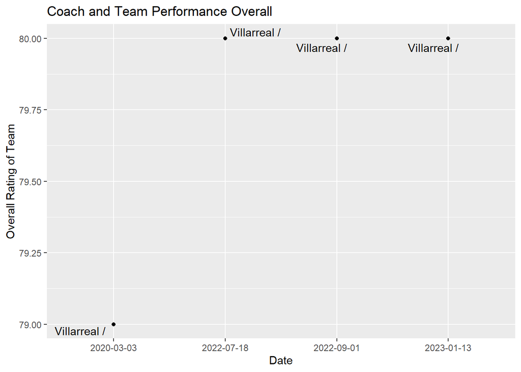

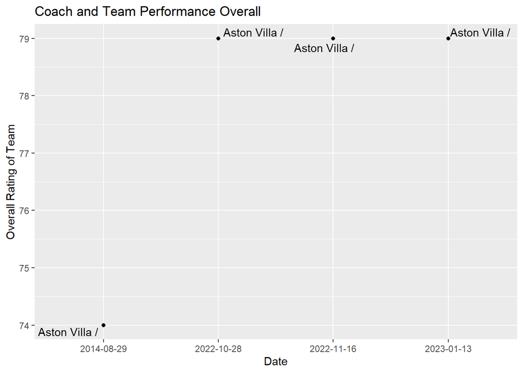

Here the x-axis shows the date the data was collected, and the y-axis shows the overall rating of the team. The format of labeling is (Team/Coach), and shows the points where a coach joined the team and when they left to compare ratings at both time periods.

In the second plot, Aston Villa ended 2014 with a rating of 74 when S. Gerrard joined as coach. When he left in October 2022, the team’s rating rested at 79, increasing 5 points under his tenure. U. Emery then joined recently, so has not changed the team’s rating at all.

## Defence Players and Goalkeepers

Let’s explore the stats of defence players and goalkeeper overalls in the subset we chose:

```r
newPlayers$gkOverall <- as.numeric(newPlayers$gkOverall)
newPlayers$overall <- as.numeric(newPlayers$overall)

st(newPlayers[, c("gkOverall", "overall")],
    labels = c("GK Overall", "DF Player Overall"),
    title = "Summary of Defence and Goalkeeper Player Statistics",
    col.align = "right",
    out = "return"
) %>%
    kbl(caption = "Summary of Defence and Goalkeeper Player Statistics") %>%
    kable_styling()
```

Summary of Defence and Goalkeeper Player Statistics

| Variable | N | Mean | Std. Dev. | Min | Pctl. 25 | Pctl. 75 | Max |
| --- | --- | --- | --- | --- | --- | --- | --- |
| GK Overall | 7875 | 69 | 6.6 | 43 | 65 | 73 | 91 |
| DF Player Overall | 7875 | 69 | 6 | 47 | 65 | 72 | 88 |

We can see some examples of how a goalkeeper’s overall changes over time after a defence player joins a team:

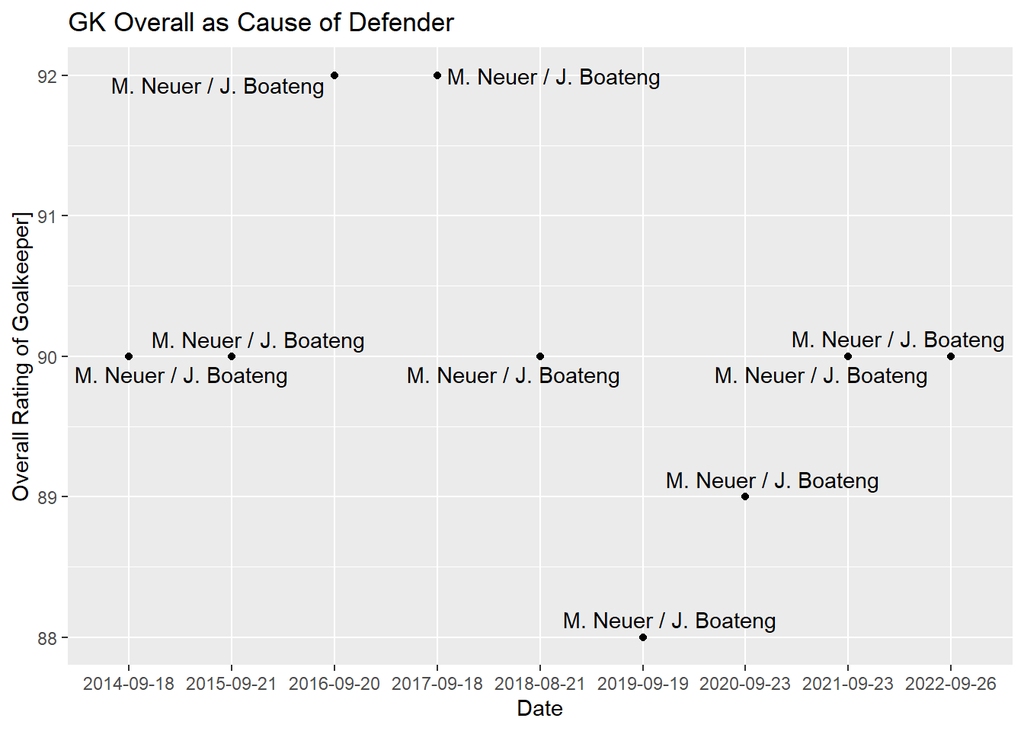

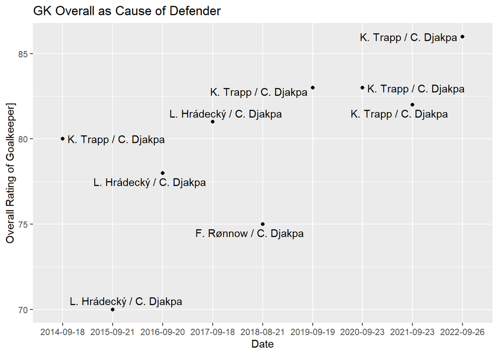

Like in the previous section, the x-axis shows the date the data was collected, and the y-axis shows the overall rating of the goalkeeper. The format for the point labels is (Goalkeeper Name/Defender Name), and shows the points where a goalkeeper joins the defender’s team and when they leave to compare the overall rating at both time periods.

# Models

## Coaches and Teams

To explore the impact of predictors on the overall of a team, we will first use a random forest. It will run on all predictors, and act as a classifier to see whether the overall of a team is higher than the mean of all teams’ overalls. The random forest will detail the “importance” of the predictors for us, telling us which has the biggest impact on the response.

```r
set.seed(1)
split <- 0.7
sample <- sample(nrow(newTeams), split * nrow(newTeams))
trainDataTeams <- newTeams[sample, ]
testDataTeams <- newTeams[-sample, ]
rfTeams <- randomForest(as.factor(overall > mean(overall)) ~ .,
    data = trainDataTeams, ntree = 500, mtry = 7,
    importance = TRUE, na.action = na.exclude)

predictions <- predict(rfTeams, testDataTeams)
cmRF <- confusionMatrix(predictions, as.factor(testDataTeams$overall > mean(testDataTeams$overall)))
print(cmRF)
```

```
## Confusion Matrix and Statistics
##
##           Reference
## Prediction FALSE TRUE
##      FALSE  5457   10
##      TRUE     17 4309
##
##                Accuracy : 0.9972
##                  95% CI : (0.996, 0.9982)
##     No Information Rate : 0.559
##     P-Value [Acc > NIR] : <2e-16
##
##                   Kappa : 0.9944
##
##  Mcnemar's Test P-Value : 0.2482
##
##             Sensitivity : 0.9969
##             Specificity : 0.9977
##          Pos Pred Value : 0.9982
##          Neg Pred Value : 0.9961
##              Prevalence : 0.5590
##          Detection Rate : 0.5572
##    Detection Prevalence : 0.5583
##       Balanced Accuracy : 0.9973
##
##        'Positive' Class : FALSE
##
```

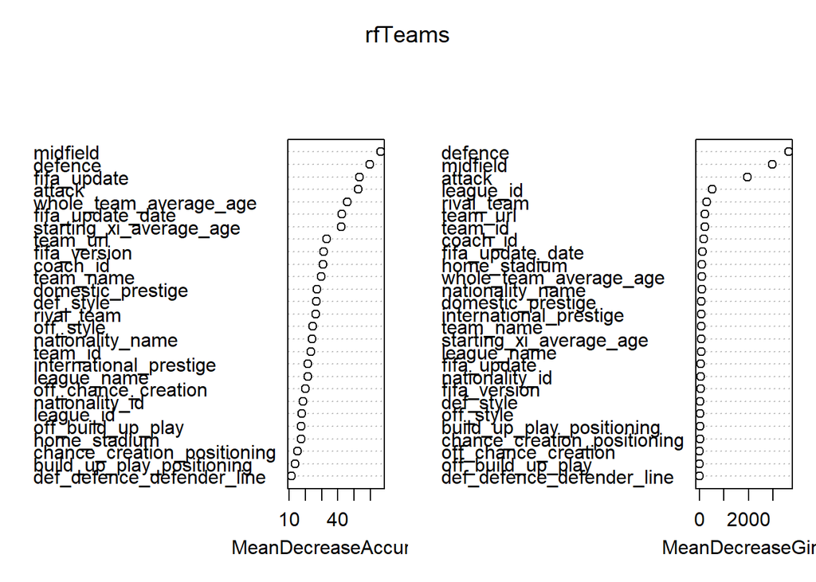

```r
varImpPlot(rfTeams)
```

```r
pred2 <- predict(rfTeams, testDataTeams, type = "prob")
pred3 <- prediction(pred2[, 2], as.factor(testDataTeams$overall > mean(testDataTeams$overall)))
auc <- performance(pred3, "auc")@y.values[[1]]
cat("AUC: ", auc)
```

```
## AUC:  0.9997664
```

As we can see, coach_id doesn’t rank as high as midfield, attack, or defence, meaning coaches might be less important than we thought. If we explore each predictor on its own in a logistic regression, we might discover if the random forest was correct.

For logistic regression, we will try to classify whether a team’s overall rating is higher than the mean team overall rating or not. The following models all use the same response, but use different predictors as explained in their titles.

### Logistic Regression: Testing midfield strength

First, we run LR on midfield alone as predictor:

```r
glmMidfield <- glm(as.factor(overall > mean(overall)) ~ midfield,
    data = trainDataTeams, family = binomial())

midfieldPred <- predict(glmMidfield, testDataTeams)
midfieldPred <- ifelse(midfieldPred >= 0, TRUE, FALSE)

cmMid <- confusionMatrix(as.factor(midfieldPred), as.factor(testDataTeams$overall > mean(testDataTeams$overall)))
print(cmMid)
```

```
## Confusion Matrix and Statistics
##
##           Reference
## Prediction FALSE TRUE
##      FALSE  5097  377
##      TRUE    377 3942
##
##                Accuracy : 0.923
##                  95% CI : (0.9175, 0.9282)
##     No Information Rate : 0.559
##     P-Value [Acc > NIR] : <2e-16
##
##                   Kappa : 0.8438
##
##  Mcnemar's Test P-Value : 1
##
##             Sensitivity : 0.9311
##             Specificity : 0.9127
##          Pos Pred Value : 0.9311
##          Neg Pred Value : 0.9127
##              Prevalence : 0.5590
##          Detection Rate : 0.5205
##    Detection Prevalence : 0.5590
##       Balanced Accuracy : 0.9219
##
##        'Positive' Class : FALSE
##
```

Pretty high accuracy for the predictor alone, a 92%.

```r
pred2 <- predict(glmMidfield, testDataTeams)
pred3 <- prediction(pred2, as.factor(testDataTeams$overall > mean(testDataTeams$overall)))
aucMid <- performance(pred3, "auc")@y.values[[1]]
cat("AUC:", aucMid)
```

```
## AUC: 0.9773243
```

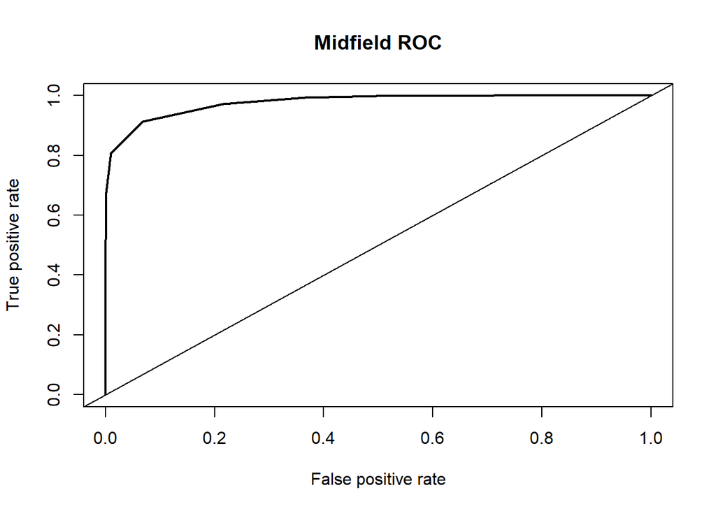

```r
perf <- performance(pred3, "tpr", "fpr")
plot(perf,
    lwd = 2,
    main = "Midfield ROC"
)
abline(a = 0, b = 1)
```

And a good ROC with a high AUC value.

### Logistic Regression: Testing attack strength

Now we check for attack alone:

```r
glmAttack <- glm(as.factor(overall > mean(overall)) ~ attack,
    data = trainDataTeams, family = binomial())

attackPred <- predict(glmAttack, testDataTeams)
attackPred <- ifelse(attackPred >= 0, TRUE, FALSE)

cmAtt <- confusionMatrix(as.factor(attackPred), as.factor(testDataTeams$overall > mean(testDataTeams$overall)))
print(cmAtt)
```

```
## Confusion Matrix and Statistics
##
##           Reference
## Prediction FALSE TRUE
##      FALSE  5059  633
##      TRUE    415 3686
##
##                Accuracy : 0.893
##                  95% CI : (0.8867, 0.899)
##     No Information Rate : 0.559
##     P-Value [Acc > NIR] : < 2.2e-16
##
##                   Kappa : 0.7818
##
##  Mcnemar's Test P-Value : 2.04e-11
##
##             Sensitivity : 0.9242
##             Specificity : 0.8534
##          Pos Pred Value : 0.8888
##          Neg Pred Value : 0.8988
##              Prevalence : 0.5590
##          Detection Rate : 0.5166
##    Detection Prevalence : 0.5812
##       Balanced Accuracy : 0.8888
##
##        'Positive' Class : FALSE
##
```

We can see a dip in accuracy here, a 88% vs the high 92% before.

```r
pred2 <- predict(glmAttack, testDataTeams)
pred3 <- prediction(pred2, as.factor(testDataTeams$overall > mean(testDataTeams$overall)))
aucAtt <- performance(pred3, "auc")@y.values[[1]]
cat("AUC:", aucAtt)
```

```
## AUC: 0.9588975
```

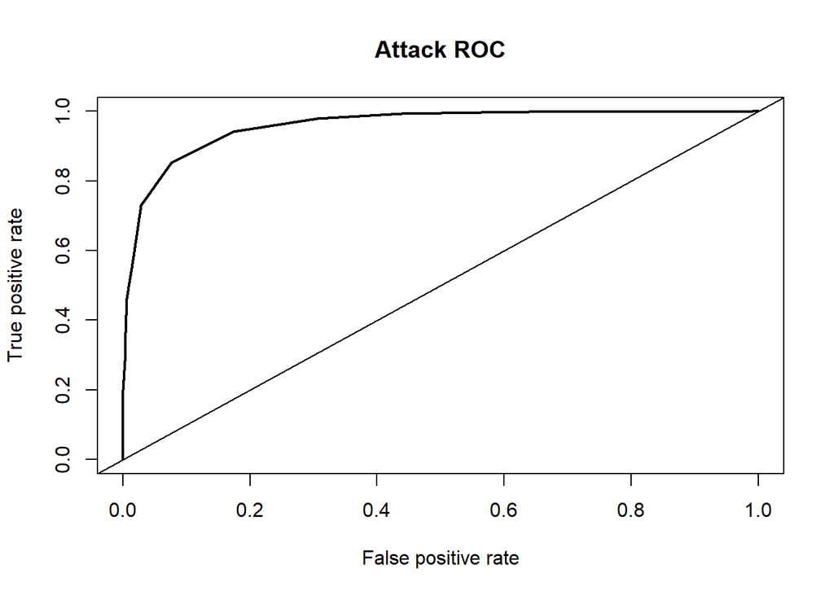

```r
perf <- performance(pred3, "tpr", "fpr")
plot(perf,
    lwd = 2,
    main = "Attack ROC"
)
abline(a = 0, b = 1)
```

But the ROC and AUC match midfield’s model.

### Logistic Regression: Testing defence strength

Next we move to defence:

```r
glmDefence <- glm(as.factor(overall > mean(overall)) ~ defence,
    data = trainDataTeams, family = binomial()
)

defencePred <- predict(glmDefence, testDataTeams)
defencePred <- ifelse(defencePred >= 0, TRUE, FALSE)

cmDef <- confusionMatrix(as.factor(defencePred), as.factor(testDataTeams$overall > mean(testDataTeams$overall)))
print(cmDef)
```

```
## Confusion Matrix and Statistics
##
##           Reference
## Prediction FALSE TRUE
##      FALSE  5312  579
##      TRUE    162 3740
##
##                Accuracy : 0.9243
##                  95% CI : (0.9189, 0.9295)
##     No Information Rate : 0.559
##     P-Value [Acc > NIR] : < 2.2e-16
##
##                   Kappa : 0.845
##
##  Mcnemar's Test P-Value : < 2.2e-16
##
##             Sensitivity : 0.9704
##             Specificity : 0.8659
##          Pos Pred Value : 0.9017
##          Neg Pred Value : 0.9585
##              Prevalence : 0.5590
##          Detection Rate : 0.5424
##    Detection Prevalence : 0.6016
##       Balanced Accuracy : 0.9182
##
##        'Positive' Class : FALSE
##
```

We see very similar results to midfield’s model.

```r
pred2 <- predict(glmDefence, testDataTeams)
pred3 <- prediction(pred2, as.factor(testDataTeams$overall > mean(testDataTeams$overall)))
aucDef <- performance(pred3, "auc")@y.values[[1]]
cat("AUC:", aucDef)
```

```
## AUC: 0.9743734
```

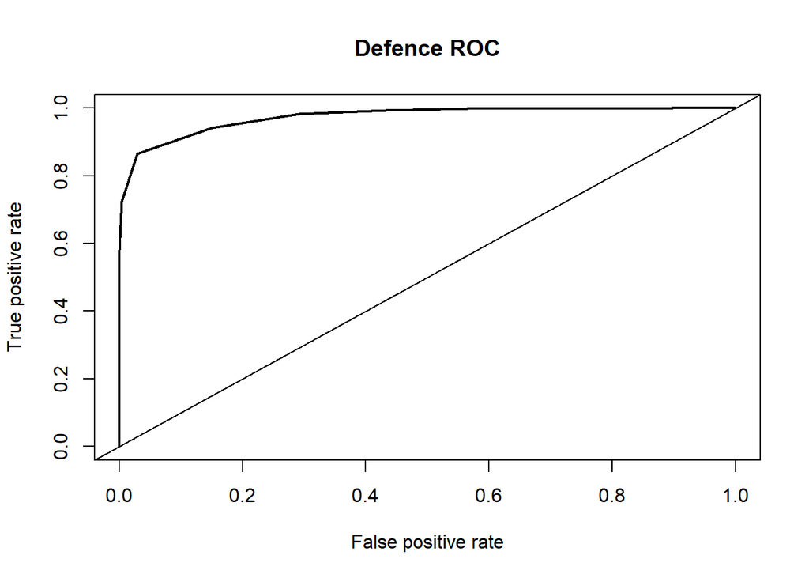

```r
perf <- performance(pred3, "tpr", "fpr")
plot(perf,
    lwd = 2,
    main = "Defence ROC"
)
abline(a = 0, b = 1)
```

And a similar ROC and AUC as well.

### Logistic Regression: Testing coach_id

Because we want to test the coaches’ impact over time, we add fifa_update_date, which describes the date a row was scraped from the games.

```r
glmCoach <- glm(as.factor(overall > mean(overall)) ~ coach_id + fifa_update_date,
    data = trainDataTeams, family = binomial()
)

coachPred <- predict(glmCoach, testDataTeams)
coachPred <- ifelse(coachPred >= 0, TRUE, FALSE)

cmCoach <- confusionMatrix(as.factor(coachPred), as.factor(testDataTeams$overall > mean(testDataTeams$overall)))
print(cmCoach)
```

```
## Confusion Matrix and Statistics
##
##           Reference
## Prediction FALSE TRUE
##      FALSE  4472 2845
##      TRUE   1002 1474
##
##                Accuracy : 0.6072
##                  95% CI : (0.5974, 0.6169)
##     No Information Rate : 0.559
##     P-Value [Acc > NIR] : < 2.2e-16
##
##                   Kappa : 0.1657
##
##  Mcnemar's Test P-Value : < 2.2e-16
##
##             Sensitivity : 0.8170
##             Specificity : 0.3413
##          Pos Pred Value : 0.6112
##          Neg Pred Value : 0.5953
##              Prevalence : 0.5590
##          Detection Rate : 0.4567
##    Detection Prevalence : 0.7472
##       Balanced Accuracy : 0.5791
##
##        'Positive' Class : FALSE
##
```

The huge dip in accuracy is apparent here, a 62% vs the 80’s and 90’s before.

```r
pred2 <- predict(glmCoach, testDataTeams)
pred3 <- prediction(pred2, as.factor(testDataTeams$overall > mean(testDataTeams$overall)))
aucCoach <- performance(pred3, "auc")@y.values[[1]]
cat("AUC:", aucCoach)
```

```
## AUC: 0.5927405
```

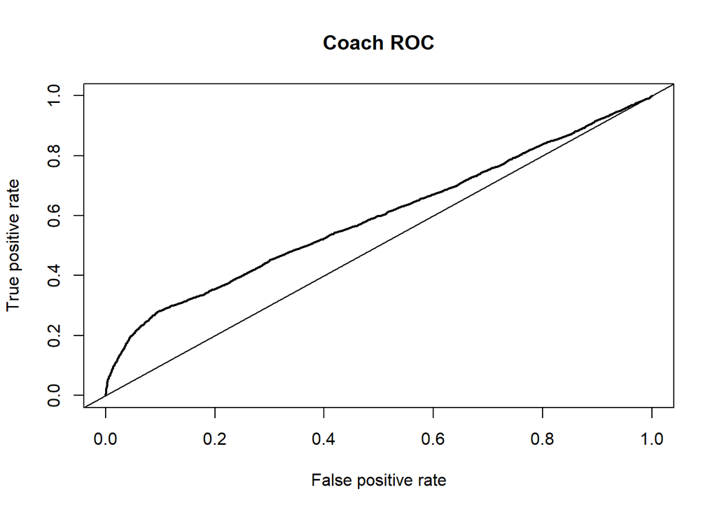

```r
perf <- performance(pred3, "tpr", "fpr")
plot(perf,
    lwd = 2,
    main = "Coach ROC"
)
abline(a = 0, b = 1)
```

The ROC and AUC don’t look good as well. The model seems unable to differentiate between true and false positives/negatives.

## Defence Players and Goalkeepers

To determine the best stats of a defence player related to determining their goalkeeper’s overall strength, we will run a random forest again with the modified newPlayers dataset and observe the importance of predictors:

### Random Forest

```r
set.seed(1)
split <- 0.7
sample <- sample(nrow(newPlayers), split * nrow(newPlayers))
trainDataPlayers <- newPlayers[sample, ]
testDataPlayers <- newPlayers[-sample, ]
rfPlayers <- randomForest(as.factor(as.numeric(gkOverall) > mean(as.numeric(gkOverall))) ~ .,
    data = trainDataPlayers, ntree = 500, mtry = 35,
    importance = TRUE
)

predictions <- predict(rfPlayers, testDataPlayers)
cmRFPlayers <- confusionMatrix(predictions, as.factor(as.numeric(testDataPlayers$gkOverall)
> mean(as.numeric(testDataPlayers$gkOverall))))
print(cmRFPlayers)
```

```
## Confusion Matrix and Statistics
##
##           Reference
## Prediction FALSE TRUE
##      FALSE  1276  407
##      TRUE     73  607
##
##                Accuracy : 0.7969
##                  95% CI : (0.7801, 0.8129)
##     No Information Rate : 0.5709
##     P-Value [Acc > NIR] : < 2.2e-16
##
##                   Kappa : 0.5677
##
##  Mcnemar's Test P-Value : < 2.2e-16
##
##             Sensitivity : 0.9459
##             Specificity : 0.5986
##          Pos Pred Value : 0.7582
##          Neg Pred Value : 0.8926
##              Prevalence : 0.5709
##          Detection Rate : 0.5400
##    Detection Prevalence : 0.7122
##       Balanced Accuracy : 0.7723
##
##        'Positive' Class : FALSE
##
```

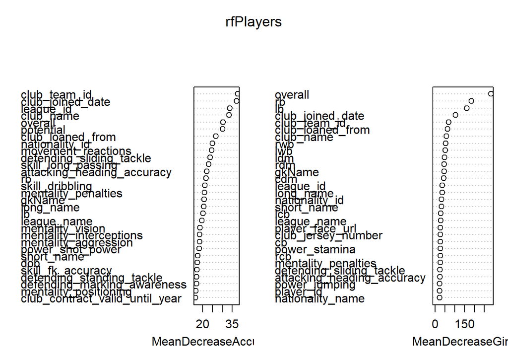

```r
varImpPlot(rfPlayers)
```

```r
pred2 <- predict(rfPlayers, testDataPlayers, type = "prob")
pred3 <- prediction(pred2[, 2], as.factor(as.numeric(testDataPlayers$gkOverall) > mean(as.numeric(testDataPlayers$gkOverall))))
aucRFPlayers <- performance(pred3, "auc")@y.values[[1]]
cat("AUC: ", aucRFPlayers)
```

```
## AUC:  0.8968141
```

A lot of the important predictors are categorical, which makes logistic regression harder with them as predictors. Instead, we will use the highest quantitative variables: “overall”, overall rating of the defence player; “rb, cb, lb, lwb, rwb, lcb, rcb”, the individual stats of the defence player if they played in those positions to predict the goalkeeper’s overall rating.

For logistic regression, we will try to classify whether a goalkeeper’s overall rating is higher than the mean goalkeeper overall rating or not using defender stats as predictors. The following models all use the same response, but use different predictors as explained in their titles.

### Logistic Regression: Testing Individual Defence Ratings

```r
glmStat <- glm(as.factor(as.numeric(gkOverall) > mean(as.numeric(gkOverall))) ~ as.numeric(rb) + as.numeric(cb) +
as.numeric(rwb) + as.numeric(lwb) + as.numeric(lb) + as.numeric(lcb) + as.numeric(rcb), data = trainDataPlayers,
family = binomial())

summary(glmStat)
```

```
##
## Call:
## glm(formula = as.factor(as.numeric(gkOverall) > mean(as.numeric(gkOverall))) ~
##     as.numeric(rb) + as.numeric(cb) + as.numeric(rwb) + as.numeric(lwb) +
##         as.numeric(lb) + as.numeric(lcb) + as.numeric(rcb), family = binomial(),
##     data = trainDataPlayers)
##
## Deviance Residuals:
##     Min       1Q   Median       3Q      Max
## -2.6487  -0.8024  -0.3362   0.7936   3.2356
##
## Coefficients: (4 not defined because of singularities)
##                  Estimate Std. Error z value Pr(>|z|)
## (Intercept)     -20.13351    0.57367 -35.096  < 2e-16 ***
## as.numeric(rb)    0.23891    0.05291   4.516 6.31e-06 ***
## as.numeric(cb)    0.07889    0.01618   4.875 1.09e-06 ***
## as.numeric(rwb)  -0.02294    0.04165  -0.551    0.582
## as.numeric(lwb)        NA         NA      NA       NA
## as.numeric(lb)         NA         NA      NA       NA
## as.numeric(lcb)        NA         NA      NA       NA
## as.numeric(rcb)        NA         NA      NA       NA
## ---
## Signif. codes:  0 '***' 0.001 '**' 0.01 '*' 0.05 '.' 0.1 ' ' 1
##
## (Dispersion parameter for binomial family taken to be 1)
##
##     Null deviance: 7534.5  on 5511  degrees of freedom
## Residual deviance: 5441.9  on 5508  degrees of freedom
## AIC: 5449.9
##
## Number of Fisher Scoring iterations: 5
```

First we use a defender’s individual stats if they played in those positions to classify the goalkeeper’s overall rating. We can see that there is some correlation happening in the model, as evidenced by the “NA” in some of the predictors. Let’s see which predictors they correlate to.

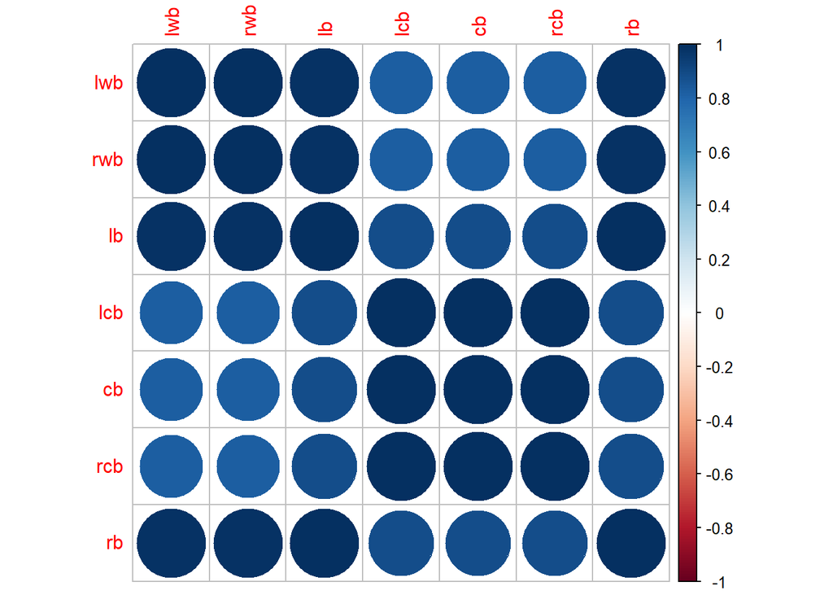

```r
corGraph <- cor(sapply(trainDataPlayers[, c(92, 96:101)], function(x) {
    as.numeric(x)
}))

colnames(corGraph) <- names(trainDataPlayers[, c(92, 96:101)])
rownames(corGraph) <- names(trainDataPlayers[, c(92, 96:101)])
corrplot(corGraph)
```

So “lb” and “rb” are linearly correlated, as are “lwb” and “rwb”, and “cb” and “lcb” and “rcb”. We can reduce the number of predictors by removing all but one of every correlating group of predictors. Once we train again, it will be without any redundancies.

```r
glmStat <- glm(
    as.factor(as.numeric(gkOverall) > mean(as.numeric(gkOverall))) ~ as.numeric(rb) + as.numeric(cb) +
        as.numeric(rwb),
    data = trainDataPlayers,
    family = binomial()
)

statPred <- predict(glmStat, testDataPlayers)
statPred <- ifelse(statPred >= 0, TRUE, FALSE)
cmPosition <- confusionMatrix(as.factor(statPred), as.factor(as.numeric(testDataPlayers$gkOverall) > mean(as.numeric(testDataPlayers$gkOverall))))
print(cmPosition)
```

```
## Confusion Matrix and Statistics
##
##           Reference
## Prediction FALSE TRUE
##      FALSE  1134  335
##      TRUE    215  679
##
##                Accuracy : 0.7672
##                  95% CI : (0.7497, 0.7842)
##     No Information Rate : 0.5709
##     P-Value [Acc > NIR] : < 2.2e-16
##
##                   Kappa : 0.5179
##
##  Mcnemar's Test P-Value : 3.892e-07
##
##             Sensitivity : 0.8406
##             Specificity : 0.6696
##          Pos Pred Value : 0.7720
##          Neg Pred Value : 0.7595
##              Prevalence : 0.5709
##          Detection Rate : 0.4799
##    Detection Prevalence : 0.6217
##       Balanced Accuracy : 0.7551
##
##        'Positive' Class : FALSE
##
```

The accuracy is lower than we imagined, with 76% accuracy.

```r
pred2 <- predict(glmStat, testDataPlayers)
pred3 <- prediction(pred2, as.factor(as.numeric(testDataPlayers$gkOverall) > mean(as.numeric(testDataPlayers$gkOverall))))
aucDefence1 <- performance(pred3, "auc")@y.values[[1]]
cat("AUC:", aucDefence1)
```

```
## AUC: 0.8427069
```

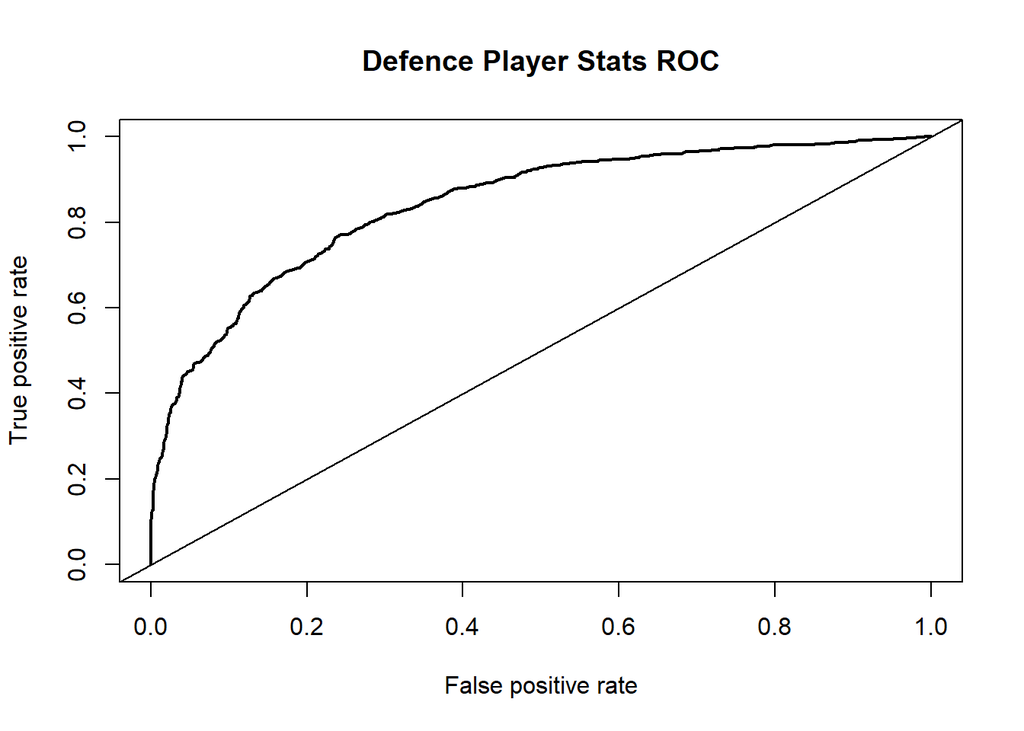

```r
perf <- performance(pred3, "tpr", "fpr")
plot(perf,
    lwd = 2,
    main = "Defence Player Stats ROC"
)
abline(a = 0, b = 1)
```

The AUC and ROC are not terrible, but maybe including a different stat will result in a better model. Using the overall of the defence player instead of their individual stats in particular positions would make a good second model.

### Logistic Regression: Testing Defence Player Overall

```r
glmOverall <- glm(as.factor(as.numeric(gkOverall) > mean(as.numeric(gkOverall))) ~ as.numeric(overall), data = trainDataPlayers, family = binomial())

overallPred <- predict(glmOverall, testDataPlayers)
overallPred <- ifelse(overallPred >= 0, TRUE, FALSE)
cmPlayerOverall <- confusionMatrix(as.factor(overallPred), as.factor(as.numeric(testDataPlayers$gkOverall) > mean(as.numeric(testDataPlayers$gkOverall))))
print(cmPlayerOverall)
```

```
## Confusion Matrix and Statistics
##
##           Reference
## Prediction FALSE TRUE
##      FALSE  1109  290
##      TRUE    240  724
##
##                Accuracy : 0.7757
##                  95% CI : (0.7583, 0.7924)
##     No Information Rate : 0.5709
##     P-Value [Acc > NIR] : <2e-16
##
##                   Kappa : 0.5394
##
##  Mcnemar's Test P-Value : 0.0333
##
##             Sensitivity : 0.8221
##             Specificity : 0.7140
##          Pos Pred Value : 0.7927
##          Neg Pred Value : 0.7510
##              Prevalence : 0.5709
##          Detection Rate : 0.4693
##    Detection Prevalence : 0.5920
##       Balanced Accuracy : 0.7680
##
##        'Positive' Class : FALSE
##
```

Here, **“gkOverall” is the overall rating of the goalkeeper, while “overall” is the overall rating of the defender.** We got a slightly better accuracy with an increase of 1%.

```r
pred2 <- predict(glmOverall, testDataPlayers)
pred3 <- prediction(pred2, as.factor(as.numeric(testDataPlayers$gkOverall) > mean(as.numeric(testDataPlayers$gkOverall))))
aucDefence2 <- performance(pred3, "auc")@y.values[[1]]
cat("AUC:", aucDefence2)
```

```
## AUC: 0.846897
```

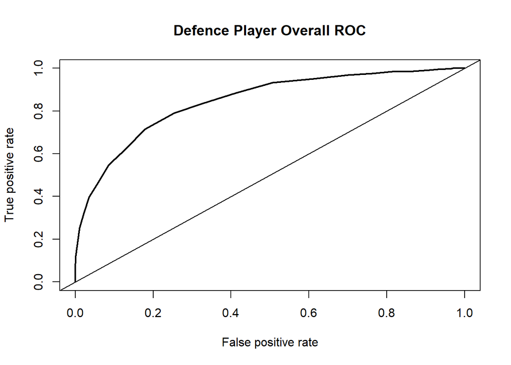

```r
perf <- performance(pred3, "tpr", "fpr")
plot(perf,
    lwd = 2,
    main = "Defence Player Overall ROC"
)
abline(a = 0, b = 1)
```

And also a very small increase in AUC. Using overall better encapsulates the abilties of a player than individual positions, which may have lead to this increase. Lastly, adding the date a player joins the team might affect the accuracy.

### Logistic Regression: Testing Defence Player Overall and Date Joined Club

```r
glmOverallDate <- glm(as.factor(as.numeric(gkOverall) > mean(as.numeric(gkOverall))) ~ as.numeric(overall) + club_joined_date, data = trainDataPlayers, family = binomial())
summary(glmOverallDate)
```

```
##
## Call:
## glm(formula = as.factor(as.numeric(gkOverall) > mean(as.numeric(gkOverall))) ~
##     as.numeric(overall) + club_joined_date, family = binomial(),
##     data = trainDataPlayers)
##
## Deviance Residuals:
##     Min       1Q   Median       3Q      Max
## -2.7001  -0.7324  -0.1754   0.6963   3.3132
##
## Coefficients:
##                        Estimate Std. Error z value Pr(>|z|)
## (Intercept)          -4.033e+01  1.994e+02  -0.202    0.840
## as.numeric(overall)   3.188e-01  9.191e-03  34.690   <2e-16 ***
## club_joined_date1997  7.665e-01  3.961e+03   0.000    1.000
## club_joined_date2001  3.654e+01  3.961e+03   0.009    0.993
## club_joined_date2002  1.490e+01  1.994e+02   0.075    0.940
## club_joined_date2003  1.615e+01  1.994e+02   0.081    0.935
## club_joined_date2004  1.818e+01  1.994e+02   0.091    0.927
## club_joined_date2005  1.644e+01  1.994e+02   0.082    0.934
## club_joined_date2006  1.822e+01  1.994e+02   0.091    0.927
## club_joined_date2007  1.773e+01  1.994e+02   0.089    0.929
## club_joined_date2008  1.805e+01  1.994e+02   0.091    0.928
## club_joined_date2009  1.755e+01  1.994e+02   0.088    0.930
## club_joined_date2010  1.839e+01  1.994e+02   0.092    0.926
## club_joined_date2011  1.783e+01  1.994e+02   0.089    0.929
## club_joined_date2012  1.843e+01  1.994e+02   0.092    0.926
## club_joined_date2013  1.817e+01  1.994e+02   0.091    0.927
## club_joined_date2014  1.803e+01  1.994e+02   0.090    0.928
## club_joined_date2015  1.795e+01  1.994e+02   0.090    0.928
## club_joined_date2016  1.836e+01  1.994e+02   0.092    0.927
## club_joined_date2017  1.844e+01  1.994e+02   0.093    0.926
## club_joined_date2018  1.825e+01  1.994e+02   0.092    0.927
## club_joined_date2019  1.828e+01  1.994e+02   0.092    0.927
## club_joined_date2020  1.817e+01  1.994e+02   0.091    0.927
## club_joined_date2021  1.869e+01  1.994e+02   0.094    0.925
## club_joined_date2022  1.798e+01  1.994e+02   0.090    0.928
## ---
## Signif. codes:  0 '***' 0.001 '**' 0.01 '*' 0.05 '.' 0.1 ' ' 1
##
## (Dispersion parameter for binomial family taken to be 1)
##
##     Null deviance: 7534.5  on 5511  degrees of freedom
## Residual deviance: 4921.6  on 5487  degrees of freedom
## AIC: 4971.6
##
## Number of Fisher Scoring iterations: 16
```

```r
overallPredDate <- predict(glmOverallDate, testDataPlayers)
overallPredDate <- ifelse(overallPredDate >= 0, TRUE, FALSE)
cmOverallDate <- confusionMatrix(as.factor(overallPredDate), as.factor(as.numeric(testDataPlayers$gkOverall) > mean(as.numeric(testDataPlayers$gkOverall))))
print(cmOverallDate)
```

```
## Confusion Matrix and Statistics
##
##           Reference
## Prediction FALSE TRUE
##      FALSE  1120  272
##      TRUE    229  742
##
##                Accuracy : 0.788
##                  95% CI : (0.7709, 0.8043)
##     No Information Rate : 0.5709
##     P-Value [Acc > NIR] : <2e-16
##
##                   Kappa : 0.565
##
##  Mcnemar's Test P-Value : 0.0606
##
##             Sensitivity : 0.8302
##             Specificity : 0.7318
##          Pos Pred Value : 0.8046
##          Neg Pred Value : 0.7642
##              Prevalence : 0.5709
##          Detection Rate : 0.4740
##    Detection Prevalence : 0.5891
##       Balanced Accuracy : 0.7810
##
##        'Positive' Class : FALSE
##
```

Now we add as predictor the date the defender joins the goalkeeper’s team in addition to the defender’s overall rating. The accuracy improves a bit with the new predictor.

```r
pred2 <- predict(glmOverallDate, testDataPlayers)
pred3 <- prediction(pred2, as.factor(as.numeric(testDataPlayers$gkOverall) > mean(as.numeric(testDataPlayers$gkOverall))))
aucDefence3 <- performance(pred3, "auc")@y.values[[1]]
cat("AUC:", aucDefence3)
```

```
## AUC: 0.8674385
```

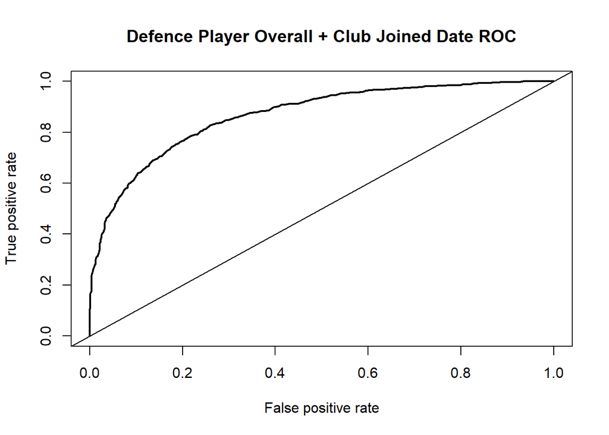

```r
perf <- performance(pred3, "tpr", "fpr")
plot(perf,
    lwd = 2,
    main = "Defence Player Overall + Club Joined Date ROC"
)
abline(a = 0, b = 1)
```

But reports similar AUC and ROC.

# Results and Analysis

## Coaches and Teams

### Summary of Test Data Model Comparision

| Model | Accuracy | AUC | Precision | Recall | F1 |
| --- | --- | --- | --- | --- | --- |
| Random Forest (All Predictors) | 0.9972429 | 0.9997664 | 0.9981708 | 0.9968944 | 0.9975322 |
| LR Midfield | 0.9230062 | 0.9773243 | 0.9311290 | 0.9311290 | 0.9311290 |
| LR Attack | 0.8929848 | 0.9588975 | 0.8887913 | 0.9241871 | 0.9061437 |
| LR Defence | 0.9243337 | 0.9743734 | 0.9017145 | 0.9704056 | 0.9347998 |
| LR Coach (Over Time) | 0.6071684 | 0.5927405 | 0.6111794 | 0.8169529 | 0.6992417 |

As we can see, the accuracies for midfield, attack, and defence classifiers were much higher than the coach over-time classifier, in the range of 80-90%. The result may be due to the distribution of quantitative values in the former three as opposed to the two categorical predictors coach_id and fifa_update_date.

But it brings to mind a question: as a coach, they strategize plans and formations for the team. Wouldn’t the coach have a hand in a team’s defence, midfield, and attack strength? It’s hard to answer without more data to follow through with. With the data we have on hand, we can conclde temporarily for our first two questions: **Defence, Midfield, and Attack can help predict a team’s overall performance better than who the coach is. The three stats can be related to how the coach delegates his team, and would need more in-depth data to study.**

## Defence Players and Goalkeepers

### Summary of Test Data Model Comparision

| Model | Accuracy | AUC | Precision | Recall | F1 |
| --- | --- | --- | --- | --- | --- |
| Random Forest (All Predictors) | 0.7968684 | 0.8968141 | 0.7581699 | 0.9458858 | 0.8416887 |
| LR Defender Position Stats | 0.7672450 | 0.8427069 | 0.7719537 | 0.8406227 | 0.8048261 |
| LR Defender Overall | 0.7757088 | 0.8468970 | 0.7927091 | 0.8220904 | 0.8071325 |
| LR Defender Overall + Joined Date | 0.7879814 | 0.8674385 | 0.8045977 | 0.8302446 | 0.8172200 |

As we can see, using the “overall” stat was better than using a player’s stats when in specific defending positions. The accuracy doesn’t help a lot in answering our question. A defender can classify a goalkeeper’s performance 77% of the time, which is not high enough to conclusively make our hypothesis true. Adding in when the defender joined the team increased the accuracy a little, but still not enough for our question.

The random forest showed a lot more important variables before a defender’s stats, but they were all categorical. This makes me believe which team the goalkeeper joined had a bigger impact on their overall than a defender’s performance (“club_team_id”, “club_joined_date”, “club_name”…).

# Impact

The data could be used in several ways:

1. Choosing coaches based on their improvement of previous teams. This model will not change how coaches are determined in football, but compliment it. A coach’s job is to improve a team’s performance during their tenure. A manager might use this model to fasten their decision in continuing with a certain coach or choosing which coach to bring next based on past achievements.
2. Choosing defence players based on past synergy with goalkeepers. A team manager would probably buy and sell their players based on whether they work well with the goalkeepers or not. They could compare the stats of a goalkeeper when a defender joined, and their stats when the two players separate and determine a defence player’s worth based on that.
3. Betting on matches and players. The model’s could help predict slightly the performance of a goalkeeper or a team with a certain coach. We say slightly because the classifiers check if the overall is higher than the mean overall. That might not help betters a lot, but it still could be considered unethical to publish without at least a disclaimer or use privately with football managers.